# Salmon-Group20

### Tab 2: Season Plots

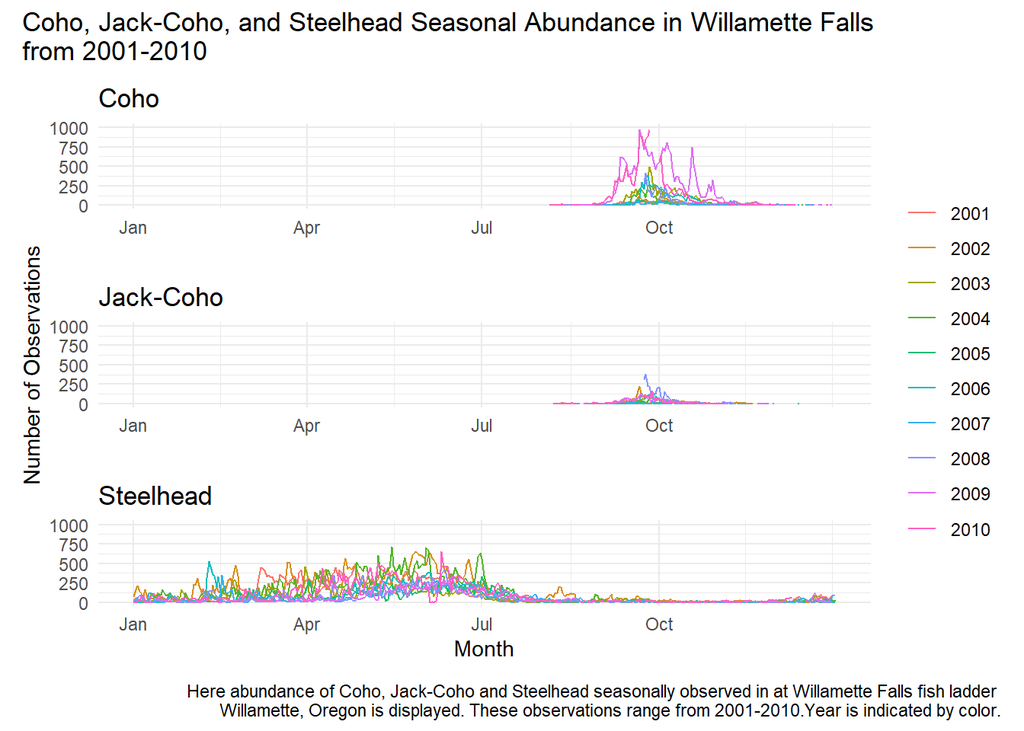

```r
willamette_long <- willamette_ts %>%
  pivot_longer(cols = chinook_run:pink,
               names_to = "species",
               values_to = "counts") %>%
  filter(species %in% c("coho", "jack_coho", "steelhead"))


coho_season <- willamette_long %>%
  filter(species == "coho") %>%
  gg_season(y = counts,
            period = "year",
            show.legend = FALSE)+
  ylim(0,1000)+
  theme_minimal()+
  labs(x= "", y = "", title = "Coho")

#coho_season

jack_coho_season <- willamette_long %>%
  filter(species == "jack_coho") %>%
  gg_season(y = counts,
            period = "year")+
  theme_minimal()+
  ylim(0,1000)+
  labs(x= "",
       y = "Number of Observations", title = "Jack-Coho")

#jack_coho_season


steelhead_season <- willamette_long %>%
  filter(species == "steelhead") %>%
  gg_season(y = counts,
            period = "year",
            show.legend = FALSE)+
  theme_minimal()+
  ylim(0,1000)+
  labs(x= "Month", y = "", title = "Steelhead")

#steelhead_season

# compound_season <- willamette_long %>%
#   gg_season(y = counts,
#             period = "year")+
#   facet_wrap(~species)+
#   theme_minimal()
#
# compound_season

patch_season <- (coho_season/jack_coho_season/steelhead_season)+
  plot_annotation(title = "Coho, Jack-Coho, and Steelhead Seasonal Abundance in Willamette Falls \nfrom 2001-2010",
                  caption = "Here abundance of Coho, Jack-Coho and Steelhead seasonally observed in at Willamette Falls fish ladder \nWillamette, Oregon is displayed. These observations range from 2001-2010.Year is indicated by color.")

patch_season
```

### Tab 3: Summary statistics and analysis

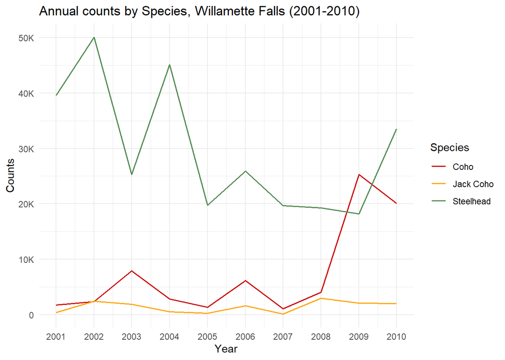

```r
willamette_fish_annual <- willamette_fish_passage %>%
  mutate(date = mdy(date)) %>%
  mutate(date_year = year(date))

coho_annual <- willamette_fish_annual %>%
  count(date_year, wt = coho)
jack_coho_annual <- willamette_fish_annual %>%
  count(date_year, wt = jack_coho)
steelhead_annual <- willamette_fish_annual %>%
  count(date_year, wt = steelhead)



ggplot()+
  geom_line(data = coho_annual, aes(x = date_year, y = n, color = "Coho"), size = 0.7) +
  geom_line(data = jack_coho_annual, aes(x = date_year, y = n, color = "Jack Coho"), size = 0.7) +
  geom_line(data = steelhead_annual, aes(x = date_year, y = n, color = "Steelhead"), size = 0.7) +
  scale_x_continuous(breaks=c(2001, 2002, 2003, 2004, 2005, 2006, 2007, 2008, 2009, 2010), limits = c(2001,2010)) +
  scale_color_manual(values = c( "Coho" = "red3", "Jack Coho" = "orange1", "Steelhead" = "palegreen4"))+
  labs(color = "Species")+
  scale_y_continuous(labels = scales::label_number_si())+
  labs(x = "Year",
       y = "Counts",
       title = "Annual counts by Species, Willamette Falls (2001-2010)") +
  theme_minimal()
```

**Figure 1.** Annual counts by species at the Willamette Falls fish ladder, Willamette River, Oregon (2001-2010). Red, orange, and green lines indicate counts for the species coho, jack coho, and steelhead, respectively. Data: [Columbia River DART](http://www.cbr.washington.edu/dart/query/adult_graph_text) (Data Access in Real Time).

**Summary**

Annual counts of coho, jack coho, and steelhead species on the Willamette Falls fish ladder (2001-2010) show the following major trends:

● An overall low number of the jack coho species for the entire time period 2001-2010

● A marked increase in the counts of individuals of the coho species for the years 2009-2010

● A high number of individuals of the steelhead species for the period 2001-2004 followed by a relative decrease in the years 2005-2009 and a recent increase in the year 2010